# The Relationship Between Deprivation, Cardiovascular and Stroke Mortality and Diabetes Medications

Naveed

2024-11-01

# Research Question

How does the prescription of diabetes medications (specifically metformin, insulin, sulphonylureases, GLP-1 antagonists and SGLT2 inhibitors) vary across socioeconomically diverse regions in Scotland and what relationship does it have with cardiovascular and stroke mortality in 2020?

## Introduction

Diabetes plays an important role in cardiovascular health with it being a major risk factor for a variety of cardiovascular diseases (NHS, 2022a). Diabetes prevalance and subsequently diabetes drug prescriptions can be influenced by a variety of factors with a significant one being deprivation. Cardiovascular and stroke pathology can often be complicated and exacerbated by the presence of diabetes.

With these factors all being intrinsically involved, this project conducts an exploratory analysis into the the relationship between deprivation, cardiovascular and stroke mortality and diabetes medications. The time scale chosen for this report is the year 2020 as the earliest data from the SIMD data is from 2020. Firstly, this report investigates the relationship between diabetes medications and deprivation scores taken from the Scottish Index of Multiple Deprivation (SIMD). The relationship between Scottish cardiovascular and stroke mortality and the diabetes medication prescriptions is then examined individually through the use of plots. Finally, the entirety of the data is summarized in a table at the end of this report to help provide a comprehensive overview of the key findings.

## The Libraries

This section contains the code for loading in all the required libraries.

```r
library(tidyverse)
library(here)
library(janitor)
library(gt)
library(sf)
library(ggspatial)
```

## The Data

This section contains the code for loading in all the required datasets that will be explored.

### Main Data

This chunk of code runs loads in the Prescriptions in Community dataset along with the “Health Board 2006” data from the Scotland open data website to be joined in with the main prescriptions data.

```r
files <- list.files(here("data", "year_data"), pattern = "csv", full.names = TRUE)

year_data <- files %>%
  map_dfr(~read_csv(., col_types = cols(
    DMDCode = col_character()
  ))) %>%
  clean_names() %>%
  rename(hb = hbt)
#Loads in the data for prescriptions across 2022

hb_data <- read_csv("https://www.opendata.nhs.scot/dataset/9f942fdb-e59e-44f5-b534-d6e17229cc7b/resource/652ff726-e676-4a20-abda-435b98dd7bdc/download/hb14_hb19.csv") %>%
  clean_names() %>%
  select(hb, hb_name)
#Loads in the data for healthboard names
```

### Deprivation, Population and Map Data

This chunk of code loads in “SIMD 2020v2” data from the open data website that contains the deprivation index for each data zone. It also loads in the population data from the Scotland census so as to create the rate per 100k in the table.

```r
deprivation_data <- read_csv("https://www.opendata.nhs.scot/dataset/78d41fa9-1a62-4f7b-9edb-3e8522a93378/resource/acade396-8430-4b34-895a-b3e757fa346e/download/simd2020v2_22062020.csv") %>%
  select(DataZone:CA, SIMD2020V2CountryDecile, -HB, -CA)%>% #, -HB, -CA
  clean_names() #Loads in the deprivation index for each data zone

population_data <- read_csv(here( "data", "UV103_age_health_board_census.csv"), skip = 10) %>%
  rename(Spare = "...6",
         hb_name = "Health Board Area 2019",
         hb_population = Count) %>%
  filter(Age == "All people" & Sex == "All people") %>%
  select(hb_name, hb_population) %>%
  mutate(hb_name = paste("NHS", hb_name)) %>%
    clean_names() #Loads in the population data per health board
```

### GP and Geography Data

The geography dataset helps provide the datazone names as well as the council area code for each GP from the “Data Zone 2011” from the “Geography Codes and Labels” . The GP dataset from the “GP Practices and List sizes October 2020” links the practice code to the datazone which can be found from and is later merged with the geography dataset. Both can be found on the open data website.

```r
geography_data <- read_csv("https://www.opendata.nhs.scot/dataset/9f942fdb-e59e-44f5-b534-d6e17229cc7b/resource/395476ab-0720-4740-be07-ff4467141352/download/dz2011_codes_and_labels_21042020.csv") %>%
  select(DataZone, DataZoneName, CA) %>%
  clean_names() #Loads in the names for the datazone

gp_data <- read_csv("https://www.opendata.nhs.scot/dataset/f23655c3-6e23-4103-a511-a80d998adb90/resource/3a3bc00b-9780-4b97-8120-2d5da5c8a619/download/practice_contactdetails_jul2020-open-data.csv") %>%
  clean_names() %>%
  select(practice_code, data_zone) #Loads in the data for each GP so as to connect the prescriptions and datazone

gp_data <- left_join(gp_data, geography_data, by = join_by(data_zone == data_zone)) #Joins council area and datazone data along with gp practice code
```

### Mortality Data

This chunk of code loads in the “Scottish Stroke Statistics” and “Scottish Heart Disease Statistics” data from the open data website to explore the relationship between diabetes prescriptions and stroke and cardiovascular mortality.

```r
stroke_mortality_data <- read_csv("https://www.opendata.nhs.scot/dataset/f5dcf382-e6ca-49f6-b807-4f9cc29555bc/resource/285b4cbd-1e87-49fe-9e24-73d2da8166ae/download/stroke_mortalitybyca.csv") %>%
  clean_names() %>%
  filter(year == 2020) %>%
  group_by(ca) %>%
  summarise(number_of_deaths = sum(number_of_deaths, na.rm = TRUE)) %>%
  rename(stroke = number_of_deaths) #Loads in stroke deaths per council area

cardiovascular_mortality_data <- read_csv("https://www.opendata.nhs.scot/dataset/0e17f3fc-9429-48aa-b1ba-2b7e55688253/resource/fc7b42f1-4de6-48dd-b640-613fb0aa427d/download/hd_mortalitybyca.csv") %>%
  clean_names() %>%
  filter(year == 2020) %>%
  group_by(ca) %>%
  summarise(number_of_deaths = sum(number_of_deaths, na.rm = TRUE)) %>%
  rename(cardiovascular = number_of_deaths) #Loads in cardiovascular deaths per council area

mortality_data <- full_join(stroke_mortality_data, cardiovascular_mortality_data) #Combines the mortality datasets
```

## Joining The Datasets

This section of code joins the various datasets of interest to create the joined data.

### Main Data

First, weightdrug_data dataframe is created by joining the prescription data with the gp data which adds in the datazones and council area codes. Then it gets filtered for the specific drugs of interest (specifically metformin, insulin, sulphonylureases, GLP-1 antagonists and SGLT2 inhibitors). After which, the health board, deprivation, population and mortality data gets added.

```r
weightdrug_data <- left_join(year_data, gp_data, by = join_by(gp_practice == practice_code)) %>%
  #Adds in datazone and council area codes
  filter(str_detect(bnf_item_description, "METFORMIN|INSULIN|GLUTIDE|OZEMPIC|SAXENDA|TRULICITY|GLICLAZIDE|GLIPIZIDE|GLIFLOZIN"),
         is.na(data_zone) != TRUE) %>%   #Filters for relevant diabetes medications and removes missing data
  left_join(., hb_data, by = join_by(hb == hb)) %>% #Joins the health board names with the prescriptions dataset
  left_join(., deprivation_data, by = join_by(data_zone == data_zone)) %>%
  #Adds in deprivation index for each health board
  left_join(., population_data) %>%  #Adds in population data per health board
  left_join(., mortality_data) #Adds in stroke and cardiovascular mortality data
```

### Deprivation Plot Data

The dp_plot_data dataframe is created and is grouped by health board code and name. It is also grouped by the gp practice and data zone code so as to have increased specificity in the deprivation index for each data point.

```r
dp_plot_data <- weightdrug_data %>%
  group_by(data_zone, gp_practice, hb, hb_name) %>%
  summarise(paid_quantity = sum(paid_quantity),
            simd = unique(simd2020v2country_decile))
  #Creates data for the deprivation plot with data from each gp practice grouped by health board
```

### Mortality Plot Data

The str_mortality_plot_data dataframe is created and is grouped by health board code and name. It is also grouped by the council area code so as to have increased specificity in the number of deaths for each data point. Sum of prescriptions, average deprivation index and stroke and cardiovascular deaths is calculated.

```r
mortality_plot_data <- weightdrug_data %>%
  group_by(hb, hb_name, ca) %>% # add bnf_item_description
  summarise(paid_quantity = sum(paid_quantity),
            average_simd_per_hb = mean(simd2020v2country_decile),
            stroke = unique(stroke),
            cardiovascular = unique(cardiovascular))
#Creates data for the mortality plot data with data from each council area grouped by health board
```

### GT Table Data

The gt_data dataframe is created and is grouped by health board code and name. The rates per 100k is created for the diabetes medication prescriptions and stroke and cardiovascular deaths.

```r
mortality_data <- mortality_plot_data %>%
  group_by(hb_name) %>%
  summarise(stroke = sum(stroke, na.rm = TRUE),
            cardiovascular = sum(cardiovascular, na.rm = TRUE)) #Calculates the number of deaths per health board

gt_data <- weightdrug_data %>%
  group_by(hb_name) %>%
  summarise(total_paid_quantity = sum(paid_quantity, na.rm = TRUE)/head(hb_population, 1) * 100000,
            hb_population = unique(hb_population),
            ar_simd = mean(simd2020v2country_decile, na.rm = TRUE)) %>%
  left_join(., mortality_data) %>%
  mutate(cardiovascular = cardiovascular/hb_population * 100000,
         stroke = stroke/hb_population * 100000) %>%
  select(-hb_population)
#Creates the rate per 100k and the SIMD average for each health board
```

## Exploratory Analysis

The next section runs through the exploratory analysis conducted to explore the relationship between deprivation, cardiovascular and stroke mortality and diabetes medications. Linear models were run simultaneously with the graphs as they can be run with multiple types of data (Castro and Aliakbar Akbaritabar, 2024).

### Graph for prescriptions vs SIMD

SIMD decile is a score between 1-10 with 1 being most deprived and 10 being least deprived. The graph subsequently created compares the prescription of diabetes drugs vs average SIMD.

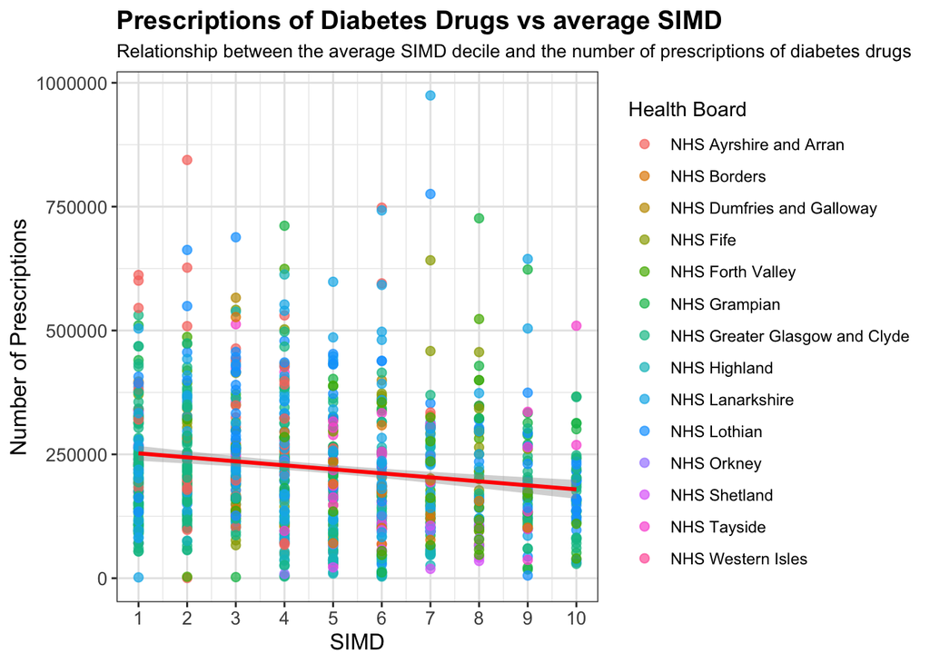

```r
dp_plot_data %>%
  ggplot(aes(x = simd, y = paid_quantity, color = hb_name)) +  # Map color to health board
  geom_point(size = 2,
    alpha = 0.7) + #Adjusts the features of the points
  geom_smooth(method = "lm", color = "red", size = 1) +  # Adds a regression line of color red
  theme_bw() +  # Adds in a special theme
  theme(axis.text.x = element_text(size = 10),
        axis.text.y = element_text(size = 10),
        axis.title = element_text(size = 12),
        plot.title = element_text(size = 14, face = "bold"),
        plot.subtitle = element_text(size = 10),
        panel.grid.major = element_line(color = "grey90", size = 0.5)) + #Adds in element parameters
  labs(title = "Prescriptions of Diabetes Drugs vs average SIMD", subtitle = "Relationship between the average SIMD decile and the number of prescriptions of diabetes drugs", x = "SIMD", y = "Number of Prescriptions", color = "Health Board") + #Adds the descriptors for the graphs
  scale_x_continuous(limits = c(1, 10), breaks = seq(1, 10, by = 1))
```

```r
deprivation_lm_model <- lm(paid_quantity ~ simd, data = dp_plot_data)
summary(deprivation_lm_model) #Generates a summary of a linear model
```

```
##
## Call:
## lm(formula = paid_quantity ~ simd, data = dp_plot_data)
##
## Residuals:
##     Min      1Q  Median      3Q     Max
## -250448  -98337  -21882   74422  770877
##
## Coefficients:
##             Estimate Std. Error t value Pr(>|t|)
## (Intercept)   260176       9058  28.724  < 2e-16 ***
## simd           -8082       1654  -4.888  1.2e-06 ***
## ---
## Signif. codes:  0 '***' 0.001 '**' 0.01 '*' 0.05 '.' 0.1 ' ' 1
##
## Residual standard error: 135500 on 927 degrees of freedom
## Multiple R-squared:  0.02512,    Adjusted R-squared:  0.02407
## F-statistic: 23.89 on 1 and 927 DF,  p-value: 1.202e-06
```

### Graph for prescriptions vs mortality

This graph was faceted by the x variable to create a plot for both stroke and cardiovascular mortality.

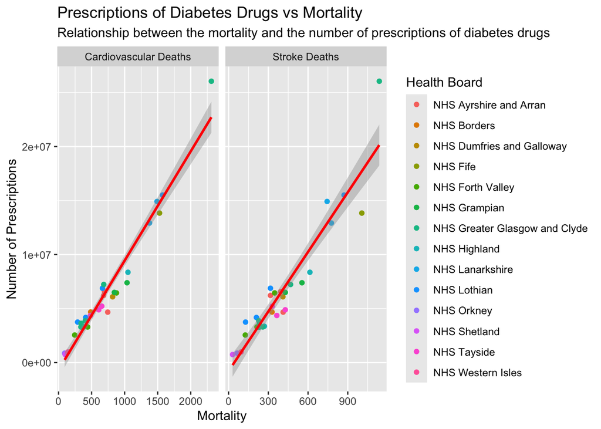

```r
mortality_plot_data_long <- mortality_plot_data %>%
  pivot_longer(cols = c(stroke, cardiovascular),
               names_to = "category",
               values_to = "value") %>% #Pivots the data to help create the graph
  mutate(category = case_when(category == "stroke" ~ "Stroke Deaths",
                              category == "cardiovascular" ~ "Cardiovascular Deaths")) #Changes the name for better readability on the graph

mortality_plot_data_long %>%
  ggplot(aes(x = value, y = paid_quantity, color = hb_name)) +
  geom_point() +
  geom_smooth(method = "lm", color = "red", size = 1) +
  labs(title = "Prescriptions of Diabetes Drugs vs Mortality", subtitle = "Relationship between the mortality and the number of prescriptions of diabetes drugs", x = "Mortality", y = "Number of Prescriptions", color = "Health Board") + #Adds in the descriptions for the plot
facet_wrap(~category, scales = "free_x") #Creates two plots one for cardiovascular mortality and stroke mortality
```

```r
mortality_lm_model <- lm(stroke+cardiovascular ~ paid_quantity, data = mortality_plot_data)
summary(mortality_lm_model) #Generates a summary of a linear model
```

```
##
## Call:
## lm(formula = stroke + cardiovascular ~ paid_quantity, data = mortality_plot_data)
##
## Residuals:
##     Min      1Q  Median      3Q     Max
## -439.00 -104.42  -38.67  128.29  383.73
##
## Coefficients:
##                Estimate Std. Error t value Pr(>|t|)
## (Intercept)   1.789e+02  5.328e+01   3.358  0.00215 **
## paid_quantity 1.424e-04  6.479e-06  21.983  < 2e-16 ***
## ---
## Signif. codes:  0 '***' 0.001 '**' 0.01 '*' 0.05 '.' 0.1 ' ' 1
##
## Residual standard error: 187.8 on 30 degrees of freedom
## Multiple R-squared:  0.9415, Adjusted R-squared:  0.9396
## F-statistic: 483.2 on 1 and 30 DF,  p-value: < 2.2e-16
```

We can see from this graph that there is clear relationship between diabetes drugs and cardiovascular and stroke mortality where we can see as the number of prescriptions increase, the number of stroke and cardiovascular deaths increase. The linear model elucidates this relationship more. The p-value is 2.2e-16 showing us that the relationship is statistically significant and with an increase of 1,000,000 prescriptions, we can see that this leads to an increase of 142.4 deaths. The R squared value is 94.15% which means that the model is a good fit and diabetes medication is a good predictor of cardiovascular and stroke mortality. This shows how important of a risk factor diabetes is for these type of diabetes.

### GT Table

The table displays the rate of number of prescriptions and number of stroke and cardiovascular deaths per 100K along with the average SIMD. It compares this among each health board and finds the overall average.

```r
gt_data %>%
  gt() %>%
     cols_label(
       total_paid_quantity = "Number of Prescriptions",
       ar_simd = "Average SIMD",
       cardiovascular = "Number of Cardiovascular Deaths",
       stroke = "Number of Stroke Deaths",
       hb_name = "Health Board Name"
     ) %>% #Renames the column names
     cols_align(
       align = "center",
       columns = everything()
     ) %>%  #Aligns the columns
 grand_summary_rows(columns = c(total_paid_quantity, ar_simd, stroke, cardiovascular), fns = list("Overall Average" = ~round(mean(., na.rm = TRUE), 2))) %>% #Adds in overall averages
     fmt_number(columns = c(total_paid_quantity, ar_simd, stroke, cardiovascular), decimals = 2) %>% #Rounds each column
     tab_header(title = "Prescriptions of Diabetes Drugs and Cardiovascular Mortality Rates and How That Compares Across Socieconomically Diverse Regions in 2020",
                subtitle = "Grouped by Health Board") %>% #Adds in titles
     tab_spanner(label = "Rate per 100k",
              columns = c(total_paid_quantity, cardiovascular, stroke)) #Adds in rate per 100k
```

Prescriptions of Diabetes Drugs and Cardiovascular Mortality Rates and How That Compares Across Socieconomically Diverse Regions in 2020

Grouped by Health Board

[output not shown]

## Conclusion

The number of pages without table of contents is 13.

## References

Castro, A.F. and Aliakbar Akbaritabar (2024). The use of linear models in quantitative research. Quantitative science studies, pp.1–32. doi:https://doi.org/10.1162/qss_a_00294.

Manson, J.E. (1991). A Prospective Study of Maturity-Onset Diabetes Mellitus and Risk of Coronary Heart Disease and Stroke in Women. Archives of Internal Medicine, 151(6), p.1141. doi:https://doi.org/10.1001/archinte.1991.00400060077013.

NHS (2022a). Cardiovascular disease. [online] NHS. Available at: https://www.nhs.uk/conditions/cardiovascular-disease/.

NHS (2022b). Prescribing for Diabetes – England – 2015/16 to 2021/22 | NHSBSA. [online] www.nhsbsa.nhs.uk. Available at: https://www.nhsbsa.nhs.uk/statistical-collections/prescribing-diabetes-england/prescribing-diabetes-england-201516-202122.